# W3cubDocs

/Qt 6.9

# ExtendedSceneEnvironment QML Type

A SceneEnvironment providing commonly used rendering effects. More...

| Import Statement: | `import QtQuick3D.Helpers` |
| --- | --- |
| Since: | Qt 6.5 |
| Inherits: | SceneEnvironment |

- [List of all members, including inherited members](https://doc.qt.io/qt-6.9/qml-qtquick3d-helpers-extendedsceneenvironment-members.html)

## Properties

- **adjustmentBrightness** : real
- **adjustmentContrast** : real
- **adjustmentSaturation** : real
- **colorAdjustmentsEnabled** : bool
- **depthOfFieldBlurAmount** : real
- **depthOfFieldEnabled** : bool
- **depthOfFieldFocusDistance** : real
- **depthOfFieldFocusRange** : real
- **ditheringEnabled** : bool
- **exposure** : real
- **fxaaEnabled** : bool
- **glowBlendMode** : int
- **glowBloom** : real
- **glowEnabled** : bool
- **glowHDRMaximumValue** : real
- **glowHDRMinimumValue** : real
- **glowHDRScale** : real
- **glowIntensity** : real
- **glowLevel** : int
- **glowQualityHigh** : bool
- **glowStrength** : real
- **glowUseBicubicUpscale** : bool
- **lensFlareApplyDirtTexture** : bool
- **lensFlareApplyStarburstTexture** : bool
- **lensFlareBloomBias** : real
- **lensFlareBloomScale** : real
- **lensFlareBlurAmount** : real
- **lensFlareCameraDirection** : vector3d
- **lensFlareDistortion** : real
- **lensFlareEnabled** : bool
- **lensFlareGhostCount** : int
- **lensFlareGhostDispersal** : real
- **lensFlareHaloWidth** : real
- **lensFlareLensColorTexture** : Texture
- **lensFlareLensDirtTexture** : Texture
- **lensFlareLensStarburstTexture** : Texture
- **lensFlareStretchToAspect** : real
- **lutEnabled** : bool
- **lutFilterAlpha** : real
- **lutSize** : real
- **lutTexture** : Texture
- **sharpnessAmount** : real
- **tonemapMode** : enumeration
- **vignetteColor** : color
- **vignetteEnabled** : bool
- **vignetteRadius** : real
- **vignetteStrength** : real
- **whitePoint** : real

## Detailed Description

The `ExtendedSceneEnvironment` is an extension of [QtQuick3D](https://doc.qt.io/qt-6.9/qtquick3d-qmlmodule.html)'s SceneEnvironment type that comes with a collection of commonly used effects built-in. The effects are exposed through a set of properties that are prefixed with the name of the effect they control.

When enabling one or more of these effects, the result is similar to manually adding post-processing effects to the SceneEnvironment's effects list. ExtendedSceneEnvironment provides however effects that are not available in standalone form, and more importantly, **it efficiently combines the effects that are enabled, reducing the number of additional render passes needed, which can lead to significantly better performance than applying individual post-processing effects** to the scene. ExtendedSceneEnvironment also plays well with tonemapping, even for the more complicated multiple pass effects, and also when multiple effects are enabled and combined together. This was not always the case with standalone effects.

**Note:** If additional post-processing effects are added to the effects list of SceneEnvironment, then those effects will be applied *before* the effects provided by the ExtendedSceneEnvironment type.

Certain features of SceneEnvironment, such as the tonemapping, are inherited and extended with additional properties in ExtendedSceneEnvironment. For example, SceneEnvironment offers the tonemapMode property, whereas ExtendedSceneEnvironment adds control over the exposure, white point, sharpening, and dithering settings of the tonemapper as well. The tonemapMode property is not duplicated however since ExtendedSceneEnvironment inherits everything from SceneEnvironment, so the base setting of the tonemapping mode is usable regardless of which type of environment is associated with a View3D, but the additional properties are available only when using ExtendedSceneEnvironment. Other effects, such as screen space ambient occlusion (SSAO) or fog are fully part of SceneEnvironment and are usable with both types of environments.

## Getting Started with ExtendedSceneEnvironment

To use the additional features offered by ExtendedSceneEnvironment, associate the View3D with an instance of it. Do not forget to import the `QtQuick3D.Helpers` module.

```
import QtQuick3D
import QtQuick3D.Helpers

View3D {
    environment: ExtendedSceneEnvironment {
        tonemapMode: SceneEnvironment.Filmic
        vignetteEnabled: true
        // ...
    }
}
```

**Note:** Experimenting with the effect parameters and tuning the values to achieve the desired visual results can often be more productive when done visually, with controls such as sliders that give instant feedback in the rendered scene when a value is changed. Using a designer tool such as Qt Design Studio, or a test bed similar to the [Qt Quick 3D - Scene Effects Example](https://doc.qt.io/qt-6.9/qtquick3d-sceneeffects-example.html) is therefore often recommendable when aiming to set up a high quality scene that looks visually appealing.

**Note:** Switching SceneEnvironment to ExtendedSceneEnvironment automatically implies at least one additional render pass, just as if an Effect with a single pass was added to the SceneEnvironment's effect list. This is true regardless of how many of the individual post-processing steps are enabled. (the more complex effects may involve more than one additional render pass)

## Available Effects

Below is an overview of the effects and related features provided by ExtendedSceneEnvironment, including features inherited from SceneEnvironment.

- Tonemapping - Controls how colors are tonemapped from high definition range to the 0-1 range before being displayed. ExtendedSceneEnvironment adds additional controls over the exposure, white point, sharpening, and dithering.

  Controlled by the properties tonemapMode, exposure, whitePoint, ditheringEnabled.

[figure not shown]

- Color adjustments - Brightness, contrast, saturation adjustment.

  Controlled by the properties colorAdjustmentsEnabled, adjustmentBrightness, adjustmentContrast, adjustmentSaturation.

[figure not shown]

- Color grading via lookup table (LUT) textures.

  Controlled by the properties lutEnabled, lutSize, lutFilterAlpha.

[figure not shown]

- Depth of field

  Controlled by the properties depthOfFieldEnabled, depthOfFieldFocusDistance, depthOfFieldFocusRange, depthOfFieldBlurAmount.

[figure not shown]

- Glow and bloom

  Controlled by the properties glowEnabled, glowQualityHigh, glowUseBicubicUpscale, glowStrength, glowIntensity, glowBloom, glowBlendMode, glowHDRMaximumValue, glowHDRMinimumValue, glowHDRScale.

[figure not shown]

- Vignette

  Controlled by the properties vignetteEnabled, vignetteStrength, vignetteColor, vignetteRadius.

[figure not shown]

- Lens flare

  Controlled by the properties lensFlareEnabled, lensFlareBloomBias, lensFlareGhostDispersal, lensFlareGhostCount, lensFlareHaloWidth, lensFlareStretchToAspect, lensFlareDistortion, lensFlareBlurAmount, lensFlareApplyDirtTexture, lensFlareApplyStarburstTexture, lensFlareCameraDirection, lensFlareLensColorTexture, lensFlareLensDirtTexture, lensFlareLensStarburstTexture.

[figure not shown]

- Screen space ambient occlusion - Provided by SceneEnvironment.

  Controlled by SceneEnvironment::aoEnabled, SceneEnvironment::aoStrength, SceneEnvironment::aoDistance, SceneEnvironment::aoSoftness, SceneEnvironment::aoDither, SceneEnvironment::aoSampleRate, SceneEnvironment::aoBias.

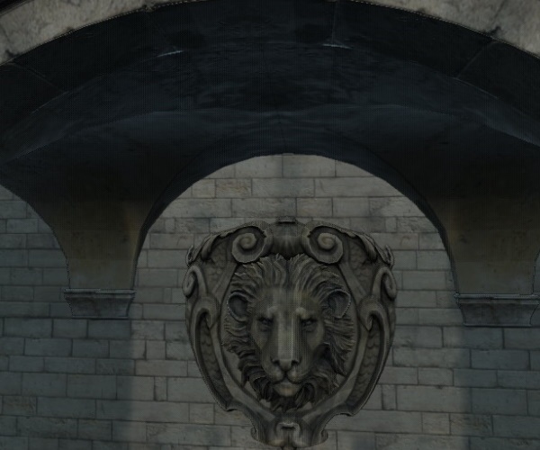

- Fog - Provided by SceneEnvironment. This is not a post-processing type of effect, but is rather applied to the materials of the renderable objects in the scene.

  Controlled by the Fog object associated with the SceneEnvironment::fog property.

[figure not shown]

- Antialiasing - Multisampling, supersampling, progressive antialiasing, specular antialiasing, temporal antialiasing are provided by SceneEnvironment. ExtendedSceneEnvironment adds the option for using a form of FXAA.

  FXAA is controlled by fxaaEnabled. Other antialiasing modes are controlled by SceneEnvironment::antialiasingMode, SceneEnvironment::temporalAAEnabled, SceneEnvironment::temporalAAStrength, and SceneEnvironment::specularAAEnabled.

[figure not shown]

**See also** SceneEnvironment and [Qt Quick 3D - Scene Effects Example](https://doc.qt.io/qt-6.9/qtquick3d-sceneeffects-example.html).

## Property Documentation

adjustmentBrightness : real `[default: 1]`

Adjusts the brightness of the scene.

Brightness of 4

[figure not shown]

adjustmentContrast : real `[default: 1]`

Adjusts the contrast of the scene.

Contrast of 4

[figure not shown]

adjustmentSaturation : real `[default: 1]`

Adjusts the saturation of the scene.

Saturation of 4

[figure not shown]

colorAdjustmentsEnabled : bool `[default: false]`

Enables color adjustments.

**See also** colorAdjustmentsEnabled.

depthOfFieldBlurAmount : real `[default: 4.0]`

Blur amount of 0

Blur amount of 15

[figure not shown]

[figure not shown]

depthOfFieldEnabled : bool `[default: false]`

Enables the depth of field blur effect.

depthOfFieldFocusDistance : real `[default: 600]`

Sets the distance from the camera at which objects are in focus.

Here the Sponza scene has a scale of `100` applied in order to have a suitably big range to get blur applied to the back and the front of the view. The picture below is taken with a focus distance of 753 and a focus range of 482.

[figure not shown]

depthOfFieldFocusRange : real `[default: 100]`

The distance around the depthOfFieldFocusDistance where items are fully in focus. The focus then fades away to fully blurred by the same distance on both the near and far sides.

ditheringEnabled : bool `[default: false]`

Enables dithering to reduce banding artifacts.

exposure : real `[default: 1.0]`

Exposure level used by the tonemapper.

Filmic tonmapping with exposure 8

Filmic tonmapping with exposure set to 0.5

[figure not shown]

[figure not shown]

fxaaEnabled : bool `[default: false]`

Enables fast approximate anti-aliasing (FXAA).

FXAA disabled

FXAA enabled

[figure not shown]

[figure not shown]

glowBlendMode : int `[default: ExtendedSceneEnvironment.GlowBlendMode.SoftLight]`

Blending mode for the glow effect.

Available modes are:

- ExtendedSceneEnvironment.GlowBlendMode.Additive
- ExtendedSceneEnvironment.GlowBlendMode.Screen
- ExtendedSceneEnvironment.GlowBlendMode.SoftLight
- ExtendedSceneEnvironment.GlowBlendMode.Replace

`Additive` is often recommendable for outdoor scenes, where a sky or sun is visible, whereas the default `SoftLight` may work better for in-door environments.

`Replace` does not perform any blending, but rather results in displaying only the contribution the glow/bloom effect would blend with the actual content. In practice this can be useful for experimenting and troubleshooting when setting up the parameters of a glow/bloom effect.

Blend mode

Example

Glow disabled

[figure not shown]

Additive

[figure not shown]

Screen

[figure not shown]

SoftLight

[figure not shown]

Replace

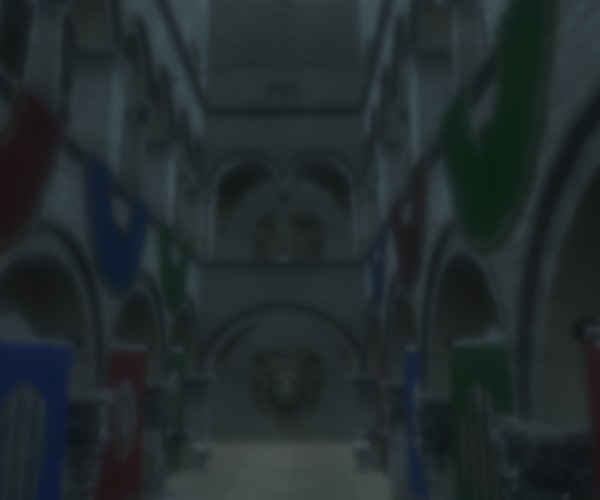

glowBloom : real `[default: 0]`

Sets the amount of bloom applied to the glow effect. Values from **0** to **1** are expected.

The glowHDRMinimumValue, glowHDRMaximumValue, glowHDRScale, and glowBloom values together control the amount of `luminance feedback` generated by the glow/bloom effect.

In practice the values for glowStrength, glowIntensity, and glowBloom will often be tuned together to achieve the desired results.

For example, with four glow levels enabled, a strength of 1.5, and an intensity of 1:

glowBloom set to 0

glowBloom set to 0.5

[figure not shown]

[figure not shown]

glowEnabled : bool `[default: false]`

Enables the glow effect. It can also provide bloom, when the value of glowBloom is larger than 0.

glowHDRMaximumValue : real `[default: 12.0]`

Sets the maximum brightness of the glow, in high dynamic range. Value range is from **0** to **256**.

The glowHDRMinimumValue, glowHDRMaximumValue, glowHDRScale, and glowBloom values together control the amount of `luminance feedback` generated by the glow/bloom effect.

glowHDRMinimumValue : real `[default: 1.0]`

Sets the minimum brightness of the glow, in high dynamic range. Expected values are in the range **0** to **4**.

The glowHDRMinimumValue, glowHDRMaximumValue, glowHDRScale, and glowBloom values together control the amount of `luminance feedback` generated by the glow/bloom effect.

glowHDRScale : real `[default: 2.0]`

The bleed scale of the HDR glow. Expected values are in the range **0** to **8**.

The glowHDRMinimumValue, glowHDRMaximumValue, glowHDRScale, and glowBloom values together control the amount of `luminance feedback` generated by the glow/bloom effect.

glowIntensity : real `[default: 1]`

Glow intensity. Expected values are in the range **0** to **8**.

The intensity is effectively a scale factor (multiplier) for the accumulated glow color (including all levels).

In practice the values for glowStrength, glowIntensity, and glowBloom will often be tuned together to achieve the desired results.

For example, with a glowStrength of 1.0 and glowBloom of 0.25:

glowIntensity of 0.25

glowIntensity of 1.25

[figure not shown]

[figure not shown]

glowLevel : int `[default: 1]`

Sets which of the blur passes get applied to the glow effect. There are a total of 7 levels available.

Not having any levels set means that the glow will have no visual effect.

For example, to enable Glow Level *One* and *Six* we just OR the two enums together:

```
glowLevel = (ExtendedSceneEnvironment.GlowLevel.One | ExtendedSceneEnvironment.GlowLevel.Six)
```

glowLevel value

Example

One

[figure not shown]

One | Two

[figure not shown]

One | Two | Three

[figure not shown]

One | Two | Three | Four

[figure not shown]

glowQualityHigh : bool `[default: false]`

Increases the samples used for the glow when downsampling to improve the quality of the glow effect.

**Note:** Enabling this is a trade off between rendering quality and performance. Consider if dithering can be used instead.

glowStrength : real `[default: 1]`

Glow strength. Acceptable values are from **0** to **2**.

The strength is effectively a scale factor (multiplier) that is applied per-level. This means the the more levels are enabled in glowLevel, the more pronounced effect a larger glowStrength has.

In practice the values for glowStrength, glowIntensity, and glowBloom will often be tuned together to achieve the desired results.

For example, with a glowIntensity of 1.0, glowBloom of 0.25, and the first four levels enabled:

glowStrength of 0.5

glowStrength of 1.5

[figure not shown]

[figure not shown]

glowUseBicubicUpscale : bool `[default: false]`

Reduces the aliasing artifacts and boxing in the glow effect.

**Note:** Using bi-cubic up-scaling will come at the cost of performance. Consider if dithering can be used instead.

lensFlareApplyDirtTexture : bool `[default: false]`

Set whether to apply a dirt texture to the lens flare.

Dirt texture disabled

Default dirty texture enabled

[figure not shown]

[figure not shown]

**See also** lensFlareLensDirtTexture.

lensFlareApplyStarburstTexture : bool `[default: false]`

Set whether to apply a starburst texture to the lens flare.

Starburst texture disabled

Default starburst texture enabled

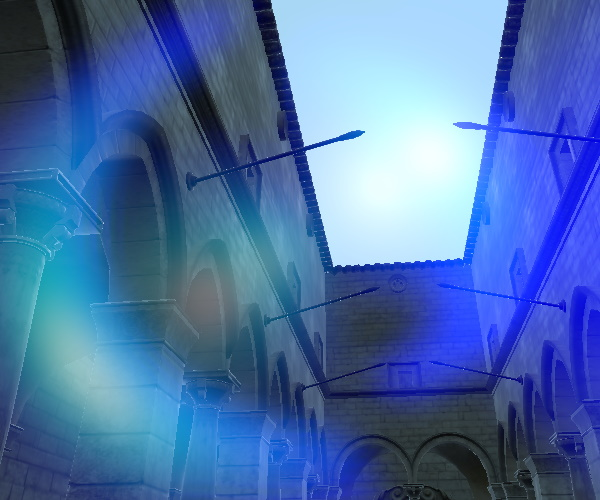

[figure not shown]

**See also** lensFlareLensStarburstTexture.

lensFlareBloomBias : real `[default: 0.95]`

Sets the level at which the lens flare bloom starts.

The bias value is subtracted from the high dynamic range color value, with the result clamped to 0. This means that, depending on the scene, it may sometimes need be set to a quite low value, e.g. below 1, in order to make the lens flare obvious. Hence the default of 0.95. Whereas when having a higher range of colors, a bigger value may make more sense.

Bias of 0.81

Bias of 0.31

[figure not shown]

[figure not shown]

lensFlareBloomScale : real `[default: 10]`

Sets the scale of the lens flare bloom effect. Expected scale value ranges from **0** to **20**.

In practice this acts as a multiplier for the zero-clamped color value with the lensFlareBloomBias subtracted.

Scale 2, bias 0.81

Scale 20, bias 0.81

[figure not shown]

[figure not shown]

lensFlareBlurAmount : real `[default: 3]`

Set amount of blur to apply to the lens flare. Ranges from **0** to **50**.

Blur amount set to 0

Blur amount set to 30

[figure not shown]

[figure not shown]

lensFlareCameraDirection : vector3d `[default: Qt.vector3d(0, 0, -1)]`

Sets the direction of the camera in the scene.

lensFlareDistortion : real `[default: 5]`

Set amount of chromatic aberration in the lens flare. Expected values ranges from **0** to **20**.

Distortion set to 0

Distortion set to 15

[figure not shown]

[figure not shown]

lensFlareEnabled : bool `[default: false]`

Enables the lens flare effect.

Once enabled, the first property to tune is typically lensFlareBloomBias.

lensFlareGhostCount : int `[default: 4]`

Sets the amount of lens flare ghosts. Expected values are from **0** to **20**.

Ghost count of 2

Ghost count of 16

[figure not shown]

[figure not shown]

lensFlareGhostDispersal : real `[default: 0.5]`

Sets the distance between the lens flare ghosts. Expected values are between **0** and **5**. The value should be larger than 0.

Ghost dispersal of 0.25

Ghost dispersal of 0.90

[figure not shown]

[figure not shown]

lensFlareHaloWidth : real `[default: 0.25]`

Sets the size of the lens flare halo. Ranges from **0** to **1**.

lensFlareLensColorTexture : Texture

A gradient image used for the lens flare lens color.

By default a built-in 256x256 texture is used:

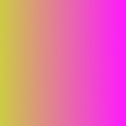

lensFlareLensDirtTexture : Texture

An image that is used to simulate inperfections on the lens.

Has an effect only when lensFlareApplyDirtTexture is enabled.

By default a built-in dirty texture is used:

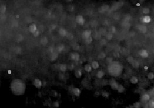

lensFlareLensStarburstTexture : Texture

A noise image to augment the starburst effect of the lens flare. Has an effect only when lensFlareApplyStarburstTexture is enabled.

By default a built-in noise texture is used:

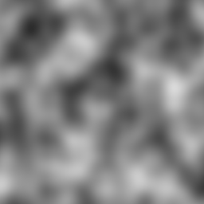

lensFlareStretchToAspect : real `[default: 0.5 [0, 1]]`

Set correction factor for roundness of the lens flare halo.

lutEnabled : bool `[default: false]`

Enables color grading with look-up tables (LUTs). The look-up table is given as a texture.

lutFilterAlpha : real `[default: 1]`

Sets the amount of color grading to mix with the scene. The value is expected to be between **0** and **1**.

lutSize : real `[default: 16]`

Sets the size of the LUT texture. The texture should have the dimensions:

`width = lutSize * lutSize` and `height = lutSize`

lutTexture : Texture

Source of look-up texture. If no texture is set a built-in identity table is used.

The result of this effect:

[figure not shown]

sharpnessAmount : real `[default: 0.0]`

Set the sharpening amount. Valid values are from `0.0` (off) to `1.0` (full).

Filmic tonmapping with sharpness set to 0

Filmic tonmapping with sharpness set to 1

[figure not shown]

[figure not shown]

tonemapMode : enumeration `[default: SceneEnvironment.TonemapModeLinear]`

This property defines how colors are tonemapped before rendering. All rendering in Qt Quick 3D is performed in linear color space and can in many cases lead to generating color values that are not displayable. The tonemapMode determines the technique that is used to remap colors into a displayable range.

The default value is `SceneEnvironment.TonemapModeLinear`

| Constant | Description |
| --- | --- |
| `SceneEnvironment.TonemapModeNone` | All Tonemapping is bypassed. This mode is useful when performing post processing effects. |
| `SceneEnvironment.TonemapModeLinear` | Linear tonemapping is applied. Colors are gamma corrected and returned in sRGB color space. |
| `SceneEnvironment.TonemapModeAces` | Academy Color Encoding System tonemapping is applied. |
| `SceneEnvironment.TonemapModeHejlDawson` | Hejl-Dawson tonemapping is applied. |
| `SceneEnvironment.TonemapModeFilmic` | Filmic tonemapping is applied. |

**Note:** When using post-processing effects, many effects expect untonemapped linear color data. It is important to bypass the built-in tonemapping in this case by using the `SceneEnvironment.TonemapModeNone` value. This does not apply to the built-in effects of ExtendedSceneEnvironment because those automatically take care of proper tonemapping.

Tonemap mode

Example

None

[figure not shown]

Linear

[figure not shown]

Aces

[figure not shown]

HejlDawson

[figure not shown]

Filmic

[figure not shown]

vignetteColor : color `[default: "gray"]`

Sets the color of the vignette effect.

For example, changing the color to red, pictured here with radius 4 and strength 15:

[figure not shown]

vignetteEnabled : bool `[default: false]`

Enables the vignette effect.

vignetteRadius : real `[default: 0.35]`

Sets the radius of the vignette effect. Ranges from **0** to **5**.

Radius of 0.35

Radius of 5.0

[figure not shown]

[figure not shown]

vignetteStrength : real `[default: 15]`

Sets the strength of the vignette effect. Ranges from **0** to **15**.

[figure not shown]

[figure not shown]

whitePoint : real `[default: 1]`

Reference value for *white* when tonemapping is enabled. The value must be larger than 0.

**Note:** This value is ignored when using SceneEnvironment.TonemapModeLinear.

Filmic tonmapping with white point set to 0.1

Filmic tonmapping with white point set to 1

[figure not shown]

[figure not shown]

© The Qt Company Ltd  
Licensed under the GNU Free Documentation License, Version 1.3.  
https://doc.qt.io/qt-6.9/qml-qtquick3d-helpers-extendedsceneenvironment.html